# Framework_Artigo Parapiqueria

# 7. Producing final matrix models

## 7.1 Transform observed recruitment in F matrices

```r
Recruit_asmx<- RepTot %>%
  mutate(id = paste0("Plot_", Plot, "_", year)) %>%  # Produce a list of plots_year similar to U_list
  mutate(
    fecundity = t1 / t0,  # fecundidade observada bruta
#    fecundity = ifelse(is.nan(fecundity) | fecundity < 0, 0, fecundity), # segurança
    F_matrix = map(fecundity, ~ {
      mat <- matrix(0, nrow=2, ncol=2)
      mat[1,2] <- .x
      mat
    })
  )


F_list <- Recruit_asmx %>%
  select(id, F_matrix) %>%
  mutate(id = as.character(id)) %>%
  { set_names(.$F_matrix, .$id) }


F_list[[1]]
```

```
     [,1]     [,2]
[1,]    0 2.238095
[2,]    0 0.000000
```

## 7.2. Merging F matrices and U matrices

```r
# Align the matrices to make sure F is defined for the correct plot

common_names <- intersect(names(U_list), names(F_list))

# 2. Subsetar e reordenar as listas
U_list_aligned <- U_list[common_names]
F_list_aligned <- F_list[common_names]

#Check if names are aligned
names(F_list_aligned) == names(U_list_aligned)
```

```
 [1] TRUE TRUE TRUE TRUE TRUE TRUE TRUE TRUE TRUE TRUE TRUE TRUE TRUE TRUE TRUE TRUE TRUE
[18] TRUE TRUE TRUE TRUE TRUE TRUE TRUE TRUE TRUE TRUE TRUE TRUE TRUE TRUE TRUE TRUE TRUE
[35] TRUE TRUE TRUE TRUE TRUE TRUE TRUE TRUE TRUE TRUE TRUE TRUE TRUE TRUE TRUE TRUE TRUE
[52] TRUE TRUE TRUE TRUE TRUE
```

```r
mpm_list <-Map(`+`, U_list_aligned, F_list_aligned)
```

### 7.3. Separe MPMs by streams

Split plots according to the streams.

- Plots 1-10 are placed in the S11C;
- Plots 11-20 are placed in the S11B;

```r
mpm_list_S11C<-mpm_list[grep("^Plot_([1-9]|10)_.*$", names(mpm_list))]
mpm_list_S11B<-mpm_list[grep("^Plot_(1[1-9]|20)_.*$", names(mpm_list))]
```

# 8. Summary results

Transform vital rates into a data.frame to proceed with statistical analyses

```r
#Accomodate matrices in two different datasets
F_mxdf<-data.frame(do.call(rbind,lapply(F_list,as.vector)),VR="vr")%>%rownames_to_column(var = "plot_year")

U_mxdf<-data.frame(do.call(rbind,lapply(U_list,as.vector)),VR="vr")%>%rownames_to_column(var = "plot_year")

# Merge these datasets
vr.df<-left_join(by="plot_year",
U_mxdf%>%  select(-X3),   #For dataset of U matrices, Recruitment (X3) is not relevant
F_mxdf%>%  select(c(plot_year,X3)) #For dataset of F matrices, Recruitment (X3) is the unique relevant informatiob
)%>% relocate(X3, .before = X4)%>%
setNames(c("plot_year","S1","S2","R","S4","VR"))%>%
separate("plot_year",sep="_",into = c("x", "Plot", "year"))%>%
select(-x)%>%
pivot_longer(S1:S4,values_to="value",names_to="vital_rate")%>%
mutate(Plot=as.numeric(Plot),
     year=year)%>%
mutate(Site=ifelse(Plot<11,"S11C","S11B"))
```

## 8.1. Overall Vital rates

```r
vr.df%>%
filter(vital_rate!=c("S4"))%>%
statrep(., group_vars = c("vital_rate"),value_var = "value")
```

| vital_rate | Mean | SD | N | SE | CI | lower95 | higher95 |
| --- | --- | --- | --- | --- | --- | --- | --- |
| R | 1.586 | 1.427 | 76 | 0.164 | 0.321 | 0.263 | 5.574 |
| S1 | 0.143 | 0.154 | 76 | 0.018 | 0.035 | 0.000 | 0.497 |
| S2 | 0.776 | 0.252 | 76 | 0.029 | 0.057 | 0.146 | 1.000 |

## 8.2. Vital rates by plot

```r
vr.df%>%
filter(vital_rate!=c("S4"))%>%
  statrep(., group_vars = c("vital_rate", "Site"),value_var = "value")%>%
    group_by(Site)%>% group_split()
```

```
<list_of<
  tbl_df<
    vital_rate: character
    Site      : character
    Mean      : double
    SD        : double
    N         : double
    SE        : double
    CI        : double
    lower95   : double
    higher95  : double
  >
>[2]>
[[1]]
```

| vital_rate | Site | Mean | SD | N | SE | CI | lower95 | higher95 |
| --- | --- | --- | --- | --- | --- | --- | --- | --- |
| R | S11B | 1.221 | 1.245 | 38 | 0.202 | 0.396 | 0.205 | 3.997 |
| S1 | S11B | 0.112 | 0.138 | 38 | 0.022 | 0.044 | 0.000 | 0.496 |
| S2 | S11B | 0.823 | 0.243 | 38 | 0.039 | 0.077 | 0.219 | 1.000 |

| vital_rate | Site | Mean | SD | N | SE | CI | lower95 | higher95 |
| --- | --- | --- | --- | --- | --- | --- | --- | --- |
| R | S11C | 1.951 | 1.524 | 38 | 0.247 | 0.485 | 0.298 | 5.377 |
| S1 | S11C | 0.174 | 0.164 | 38 | 0.027 | 0.052 | 0.000 | 0.482 |
| S2 | S11C | 0.729 | 0.254 | 38 | 0.041 | 0.081 | 0.153 | 1.000 |

```
NA
```

```r
vr.df%>%
filter(vital_rate=="R")%>%
  statrep(., group_vars = c("year", "Site"),value_var = "value")%>%
    group_by(Site)
```

| year | Site | Mean | SD | N | SE | CI | lower95 | higher95 |
| --- | --- | --- | --- | --- | --- | --- | --- | --- |
| 2022 | S11B | 0.786 | 0.577 | 9 | 0.192 | 0.377 | 0.122 | 1.834 |
| 2022 | S11C | 2.342 | 1.760 | 10 | 0.556 | 1.091 | 0.785 | 6.055 |
| 2023 | S11B | 0.988 | 0.740 | 10 | 0.234 | 0.459 | 0.279 | 2.115 |
| 2023 | S11C | 1.056 | 0.946 | 10 | 0.299 | 0.586 | 0.268 | 3.016 |
| 2024 | S11B | 1.916 | 1.860 | 10 | 0.588 | 1.153 | 0.335 | 5.502 |
| 2024 | S11C | 2.582 | 1.418 | 10 | 0.448 | 0.879 | 1.090 | 4.565 |
| 2025 | S11B | NaN | NA | 9 | NA | NA | NA | NA |
| 2025 | S11C | NaN | NA | 8 | NA | NA | NA | NA |

### 8.2.1. Checking if there is differences between plots

```r
#Stasis
vr.df%>%
filter(vital_rate=="S1")%>%
  aov(value~Site*year,data=.)%>%
  anova()
```

```
Analysis of Variance Table

Response: value
          Df  Sum Sq  Mean Sq F value   Pr(>F)
Site       1 0.07232 0.072317  5.1814  0.02598 *
year       3 0.71700 0.239002 17.1242 2.18e-08 ***
Site:year  3 0.03566 0.011887  0.8517  0.47053
Residuals 68 0.94907 0.013957
---
Signif. codes:  0 ‘***’ 0.001 ‘**’ 0.01 ‘*’ 0.05 ‘.’ 0.1 ‘ ’ 1
```

```r
#Growth
vr.df%>%
filter(vital_rate=="S2")%>%
  aov(value~Site*year,data=.)%>%
  anova()
```

```
Analysis of Variance Table

Response: value
          Df Sum Sq  Mean Sq F value   Pr(>F)
Site       1 0.1673 0.167305  3.2418 0.076215 .
year       3 0.9233 0.307753  5.9633 0.001136 **
Site:year  3 0.1484 0.049454  0.9583 0.417577
Residuals 68 3.5093 0.051608
---
Signif. codes:  0 ‘***’ 0.001 ‘**’ 0.01 ‘*’ 0.05 ‘.’ 0.1 ‘ ’ 1
```

```r
#Recruitment
vr.df%>%
filter(vital_rate=="R")%>%
  aov(value~Site*year,data=.)%>%
  anova()
```

```
Analysis of Variance Table

Response: value
          Df Sum Sq Mean Sq F value  Pr(>F)
Site       1  7.465  7.4650  4.3775 0.04151 *
year       2 13.888  6.9441  4.0721 0.02299 *
Site:year  2  5.439  2.7196  1.5948 0.21310
Residuals 50 85.266  1.7053
---
Signif. codes:  0 ‘***’ 0.001 ‘**’ 0.01 ‘*’ 0.05 ‘.’ 0.1 ‘ ’ 1
```

### 7.2.2. Checking if vital rates are correlated to year

```r
vr.df%>%
  filter(vital_rate!="S4")%>%
  filter(complete.cases(.))%>%       # Recruitment in  plot_15_2024 could not be extimeted as this plot reached exticntion in 2024.
  select(-c(Plot,Site,VR))%>%
  mutate(year=as.numeric(year))%>%
  nest(data=c(year,value))%>% #only year and value are considered here
  mutate(pairwise= map(data, ~ cor.test(.$value, .$year,method="pearson")))%>% #cor.test instead of t.test
  pull()%>%
  purrr::set_names(c("Stasis[Immat]", "Growth[Immat.>Adult]", "Recruitment"))%>%
  tibble(
    Vital_rate = names(.),
    Correlation = map_dbl(., ~ .x$estimate[1]),
    conf_low = map_dbl(., ~ .x$conf.int[1]),
    conf_high = map_dbl(., ~ .x$conf.int[2]),
    t = map_dbl(., ~ .x$statistic),
    df = map_dbl(., ~ .x$parameter),
    p_value = map_dbl(., ~ .x$p.value))
```

| . | Vital_rate | Correlation | conf_low | conf_high | t | df | p_value |
| --- | --- | --- | --- | --- | --- | --- | --- |
|  | Stasis[Immat] | 0.2694860 | 0.04687865 | 0.466592701 | 2.407264 | 74 | 0.01856661 |
|  | Growth[Immat.>Adult] | -0.2178519 | -0.42255331 | 0.007996438 | -1.920151 | 74 | 0.05869286 |
|  | Recruitment | 0.1666391 | -0.10067180 | 0.411511523 | 1.241907 | 54 | 0.21963792 |

```r
NA
```

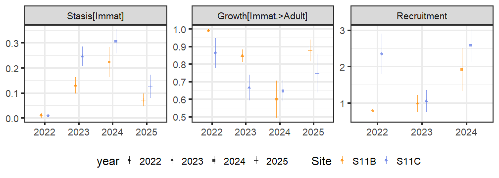

```r
vr.df%>%
  statrep(., group_vars = c("vital_rate","year","Site"))%>%
  # filter(vital_rate!="R")%>%
  mutate(VR=ifelse(vital_rate=="R","Recruitment","Survival"))%>%
  mutate(stages=case_when(vital_rate=="S1"~ "Stasis[Immat]",
                          vital_rate=="S2"~ "Growth[Immat.>Adult]",
                          vital_rate=="R"~ "Recruitment",
                          vital_rate=="S4"~ "Surv[Adult]"))%>%
  mutate(stages=forcats::fct_relevel(stages, c("Stasis[Immat]","Growth[Immat.>Adult]", "Surv[Adult]","Recruitment")))%>%
  filter(!(vital_rate %in% c("S4")))%>%
  filter(!c(vital_rate=="R" & year==2025))%>%
  ungroup()%>%
  ggplot(.,aes(y=Mean,x=year,group=Site))+
  geom_pointrange(aes(ymin=Mean-SE,ymax=Mean+SE,color=Site,shape=year),alpha=0.8,
                  position = position_dodge2(width = 0.4))+
#  scale_x_discrete(labels=function(l) parse(text=l))+
  scale_x_discrete(drop=TRUE)+
  scale_color_manual(values=c("#ff9211","#6e86e7"))+
  theme_bw(base_size=24)+
  theme(legend.position="bottom")+
  facet_wrap(.~stages,scales="free")+
  xlab(NULL)+ylab(NULL)
```

```r
lamb_df<-lapply(mpm_list,lambda)%>%
  unlist()%>%data.frame(Lambda=.)%>%
  rownames_to_column(., var = "plot_year")%>%as_tibble()%>%
  separate("plot_year",sep="_",into = c("x", "Plot", "Year"))%>%
  select(-x)%>%
  mutate(Site=ifelse(Plot<11,"S11C","S11B"))

mean(lamb_df$Lambda)
```

```
[1] 1.079875
```

```r
sd(lamb_df$Lambda)
```

```
[1] 0.4698737
```

```r
range(lamb_df$Lambda)
```

```
[1] 0.2268999 2.6299556
```

```r
#TESTING DIFFERENCES
t.test(Lambda~Site,data=lamb_df)
```

```
    Welch Two Sample t-test

data:  Lambda by Site
t = -1.0773, df = 6.0913, p-value = 0.3221
alternative hypothesis: true difference in means between group S11B and group S11C is not equal to 0
95 percent confidence interval:
 -0.7526447  0.2913387
sample estimates:
mean in group S11B mean in group S11C
          1.055162           1.285815
```

```r
lamb_df%>%statrep(., group_vars = c("Site"),value_var = "Lambda")
```

| Site | Mean | SD | N | SE | CI | lower95 | higher95 |
| --- | --- | --- | --- | --- | --- | --- | --- |
| S11B | 1.055 | 0.465 | 50 | 0.066 | 0.129 | 0.502 | 2.213 |
| S11C | 1.286 | 0.499 | 6 | 0.204 | 0.399 | 0.634 | 1.906 |

```r
lamb_df%>%statrep(., group_vars = c("Year","Site"),value_var = "Lambda")
```

| Year | Site | Mean | SD | N | SE | CI | lower95 | higher95 |
| --- | --- | --- | --- | --- | --- | --- | --- | --- |
| 2022 | S11B | 1.053 | 0.549 | 17 | 0.133 | 0.261 | 0.382 | 2.281 |
| 2022 | S11C | 1.524 | 0.039 | 2 | 0.028 | 0.054 | 1.497 | 1.550 |
| 2023 | S11B | 0.899 | 0.302 | 18 | 0.071 | 0.139 | 0.506 | 1.332 |
| 2023 | S11C | 0.712 | 0.147 | 2 | 0.104 | 0.203 | 0.613 | 0.810 |
| 2024 | S11B | 1.244 | 0.484 | 15 | 0.125 | 0.245 | 0.638 | 2.124 |
| 2024 | S11C | 1.622 | 0.473 | 2 | 0.335 | 0.656 | 1.304 | 1.940 |

```r
NA
NA
```

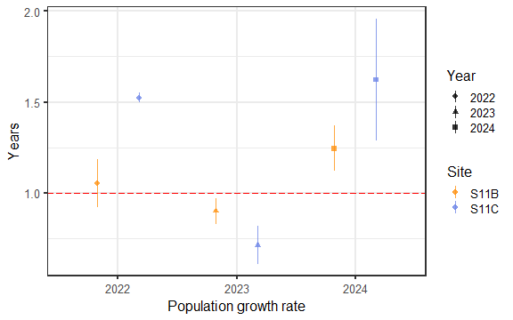

```r
lamb_df%>%
  statrep(., group_vars = c("Site","Year"),value_var = "Lambda")%>%
  #  mutate(VAR="PopGrowthRate")%>%
  ggplot(.,aes(y=Mean,x=Year,group=Site))+
  geom_hline(yintercept=1,col="red", linetype="longdash")+
  geom_pointrange(aes(ymin=Mean-SE,ymax=Mean+SE,color=Site,shape=Year),alpha=0.8,
                  position = position_dodge2(width = 0.7))+
  #  geom_line(aes(color = Site, group = Site),
  #            position = position_dodge2(width = 0.7))+
  scale_x_discrete(labels=function(l) parse(text=l))+
  scale_color_manual(values=c("#ff9211","#6e86e7"))+
  theme_bw(base_size=16)+
  theme(legend.position="right")+
#  facet_grid(.~VAR)+
  xlab("Population growth rate")+ylab("Years")
```

# 8. Applying demographic tools: elasticity and LTRE

## 8.1. Elasticities of mean demographic parameters

```r
#Elasticities
elas<-elasticity(mean(mpm_list))
elas
```

```
           [,1]      [,2]
[1,] 0.07178042 0.4641098
[2,] 0.46410979 0.0000000
```

```r
# Elasticities in Site S11B
elasticity(mean(mpm_list_S11B))
```

```
           [,1]     [,2]
[1,] 0.06391592 0.468042
[2,] 0.46804204 0.000000
```

```r
# Elasticities in Site S11C
elasticity(mean(mpm_list_S11C))
```

```
           [,1]      [,2]
[1,] 0.08009569 0.4599522
[2,] 0.45995216 0.0000000
```

## 8.2. Life Table Response Experiment (LTRE)

```r
ltre_res<-LTRE(mean(mpm_list_S11B), mean(mpm_list_S11C))
ltre_sd<-sqrt(var2(LTRE(mpm_list_S11B, mean(mpm_list_S11C))))
```

```r
vr_perf<-data.frame(
 LTRE= as.vector(ltre_res),
 LTRE_sd= as.vector(ltre_sd),
 Elasticities= as.vector(elas),
  vr=c("S11","S21","R","S22"))



vr_perf%>%
  mutate(Elasticities=Elasticities*100)
```

| LTRE | LTRE_sd | Elasticities | vr |
| --- | --- | --- | --- |
| -0.03240482 | 0.08502107 | 7.178042 | S11 |
| 0.08565325 | 0.15647284 | 46.410979 | S21 |
| -0.25452568 | 0.39387627 | 46.410979 | R |
| 0.00000000 | 0.00000000 | 0.000000 | S22 |

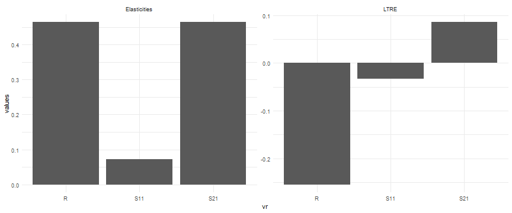

```r
vr_perf%>%pivot_longer(!c(vr, LTRE_sd),names_to="variable",values_to="values")%>%
  filter(vr!="S22")%>%
  ggplot(.,aes(x=vr,y=values))+
  geom_col()+
  facet_wrap(.~variable,scales="free")+
  theme_minimal()
```

```r
NA
```

## 8.2. Life table response by year

```r
LTREyear_df<- data.frame(
    rbind(
    #2022
        LTRE(
          mean(mpm_list_S11B[grep("2022$", names(mpm_list_S11B), value = TRUE)]),
          mean(mpm_list_S11C[grep("2022$", names(mpm_list_S11C), value = TRUE)]))%>%
          as.vector(),
    #2023
        LTRE(
          mean(mpm_list_S11B[grep("2023$", names(mpm_list_S11B), value = TRUE)]),
          mean(mpm_list_S11C[grep("2023$", names(mpm_list_S11C), value = TRUE)]))%>%
        as.vector(),
    #2024
        LTRE(
          mean(mpm_list_S11B[grep("2024$", names(mpm_list_S11B), value = TRUE)]),
          mean(mpm_list_S11C[grep("2024$", names(mpm_list_S11C), value = TRUE)]))%>%
        as.vector())
  )



LTREyear_df %>%
  rowwise() %>%
  mutate(
    total = sum(abs(c_across(everything()))),
    across(everything(), ~ abs(.x) / total)*100
  ) %>%
  select(-c(total,X4))%>%
  cbind(Year=c("2022","2023","2024"),.)%>%
    setNames(c("Year","S1","S2","R"))
```

| Year | S1 | S2 | R |
| --- | --- | --- | --- |
| 2022 | 0.1005716 | 12.19747 | 87.70196 |
| 2023 | 32.2734340 | 53.12081 | 14.60575 |
| 2024 | 18.5570418 | 22.87280 | 58.57016 |

# 9. Extinction risk

Three steps must be performed first:

3. Create a set of matrices with these new estimated variables

## 9.1. Define the initial number of individuals

```r
Mean_indiv<-Census_all_max%>%
  #filter(  Remove 1% dos dados para evitar outliers
  #  value < quantile(value,.995) &
  #  value > quantile(value,.005))%>%
  group_by(stage)%>%
  summarise(Mean=mean(value),
            Median=median(value),
            sd=sd(value))

Mean_indiv
```

| stage | Mean | Median | sd |
| --- | --- | --- | --- |
| MaxIm | 72.85714 | 55 | 71.99026 |
| MaxRep | 63.50649 | 57 | 51.56335 |
| MaxTot | 83.32468 | 70 | 70.92721 |

## 9.4. Extinction growth rate

```r
#'-------------------------------------------------------------------------
# Create proptable_modif a special prop table ------------------
#'-------------------------------------------------------------------------
## Rationale  --------------
# proptable_modif is an adaptation of default prop.table
# This function allow to include FALSE or TRUE when there is no legitime true or false extinction
#'-------------------------------------------------------------------------
proptable_modif <- function(data, threshold) {
  # equivalent to prop.table(table(apply(data,1,sum)> n_threshold))*100
  res <- table(factor(apply(data, 1, sum) > threshold, levels = c(FALSE, TRUE)))
  # Equivalent to prop.table(ext10.probS11B)*100
  prop <- prop.table(res) * 100
  return(prop)
}
##'-------------------------------------------------------------------------
```

```r
n_init<-Mean_indiv$Median[1:2] # define initial population
n_threshold<-sum(n_init)*.10 # Define extinction threshold: 10% of the initial population size

proj.pop<-stoch.quasi.ext(mpm_list,
              n0 = n_init,
              Nx=n_threshold,
              maxruns=10,
              tmax = 10, nreps=1000)
```

```
Calculating extinction probability for run 1
Calculating extinction probability for run 2
Calculating extinction probability for run 3
Calculating extinction probability for run 4
Calculating extinction probability for run 5
Calculating extinction probability for run 6
Calculating extinction probability for run 7
Calculating extinction probability for run 8
Calculating extinction probability for run 9
Calculating extinction probability for run 10
```

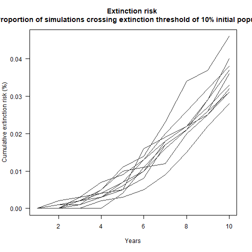

```r
matplot(proj.pop, xlab="Years", ylab="Cumulative extinction risk (%)",
        type='l', lty=1, col="grey20", las=1,
        main="Extinction risk \n (Proportion of simulations crossing extinction threshold of 10% initial population")
```

```r
#Project population for 10 years based on estimated parameters
projS11B_10<-stoch.projection(mpm_list_S11B,
                              n_init,
                              tmax=10,nreps=10000)
projS11C_10<-stoch.projection(mpm_list_S11C,
                              n_init,tmax=10,nreps=10000)


# Project with all matrices together
projALL_10<-stoch.projection(mpm_list,
                             n_init,tmax=10,nreps=10000)

projALL_30<-stoch.projection(mpm_list,
                             n_init,tmax=30,nreps=10000)
```

```r
data.frame(rbind(
  proptable_modif(projALL_10, n_threshold),
  proptable_modif(projALL_30, n_threshold)),
  row.names = c("10 years", "30 years"))%>%setNames(c("Extincted","Persistent"))%>%
  print()
```

|  | Extincted | Persistent |
| --- | --- | --- |
| 10 years | 2.37 | 97.63 |
| 30 years | 4.80 | 95.20 |

```r
NA
```

```r
# Chi-square of extinction rate between streams
data.frame(rbind(
  proptable_modif(projS11B_10, n_threshold),
  proptable_modif(projS11C_10, n_threshold)),
  row.names = c("S11B", "S11C"))%>%setNames(c("Extincted","Persistent"))%>%
  print()%>%chisq.test()
```

|  | Extincted | Persistent |
| --- | --- | --- |
| S11B | 12.07 | 87.93 |
| S11C | 0.07 | 99.93 |

```
    Pearson's Chi-squared test with Yates' continuity correction

data:  .
X-squared = 10.611, df = 1, p-value = 0.001124
```

## 9.5 Simulating different scenarios

Create a function to automatise the vital rates reduction. This function is a adaptation of `stoch.quasi.ext` from `popbio` package.

This adaptation includes the parameter “damage” with a vector informing scenarios of vital rates reduction. Note all vital rates are impacted together.

```r
Myviab_func<-function (matrices, n0, Nx, tmax = 50, maxruns = 10, nreps = 5000,
                       prob = NULL, sumweight = NULL, verbose = TRUE,damage=damage) {
  damage=damage
  if (is.list(matrices)) {
    matrices <- matrix(unlist(matrices), ncol = length(matrices))
  }
  x <- length(n0)
  if (is.null(sumweight)) {
    sumweight <- rep(1, x)
  }
  y <- dim(matrices)[2]
  ext <- matrix(numeric(maxruns * tmax), ncol = maxruns)
  for (h in 1:maxruns) {
    if (verbose) {
      message("Calculating extinction probability for run ",
              h)
    }
    prob.ext <- numeric(tmax)
    for (i in 1:nreps) {
      n <- n0
      for (t in 1:tmax) {
        col <- sample(1:y, 1, prob = prob)
        A <- matrix(matrices[, col], nrow = x)
        n <- ((A-(A*damage)) %*% n)
        N <- sum(sumweight * round(n))
        if (N < Nx) {
          prob.ext[t] <- prob.ext[t] + 1
          break
        }
      }
    }
    prob.ext <- cumsum(prob.ext/nreps) #Extinctions by number of replications
    ext[, h] <- prob.ext
  }
  ext
}
```

- Define de impacts. a sequence of impact from 0% to 50% reduction in vital rates

```r
sim_damage<-seq(0,0.5,by=0.05)
sim_damage
```

```
 [1] 0.00 0.05 0.10 0.15 0.20 0.25 0.30 0.35 0.40 0.45 0.50
```

```r
# My color system
Mycolors<-c(
  '#5e90a5', '#7e7a89', '#9e636e', '#bf4d52', '#df3637', '#ff201b', '#cc1a16', '#991310', '#660d0b', '#330605', '#000000'
#  '#A7C7E7', '#6699CC', '#FFC857', '#FF8C42', '#FF3C38', '#D7263D', '#A01227', '#6F0E19', '#3B080F', '#000000'
)
```

Calculate the number of simulations crossing the extinction threshold to extimate the persistence probability.

```r
viab_para<-do.call(rbind,out)%>%
  mutate(Persistprop=100-(Extinct.rate*100),
         ymin=100-((Extinct.rate-SD)*100),
         ymax=100-((Extinct.rate+SD)*100))

viab_para[viab_para>100]<-100
viab_para[viab_para<0]<-0


viab_para%>%filter(t==10)
```

| Extinct.rate | SD | Damage | t | Persistprop | ymin | ymax |
| --- | --- | --- | --- | --- | --- | --- |
| 0.0368 | 0.017167034 | 0.00 | 10 | 96.32 | 98.0367034 | 94.603297 |
| 0.0711 | 0.024366520 | 0.05 | 10 | 92.89 | 95.3266520 | 90.453348 |
| 0.1272 | 0.033396304 | 0.10 | 10 | 87.28 | 90.6196304 | 83.940370 |
| 0.2188 | 0.041567275 | 0.15 | 10 | 78.12 | 82.2767275 | 73.963272 |
| 0.3579 | 0.051390661 | 0.20 | 10 | 64.21 | 69.3490661 | 59.070934 |
| 0.5238 | 0.048027349 | 0.25 | 10 | 47.62 | 52.4227349 | 42.817265 |
| 0.7000 | 0.046384428 | 0.30 | 10 | 30.00 | 34.6384428 | 25.361557 |
| 0.8447 | 0.030065753 | 0.35 | 10 | 15.53 | 18.5365753 | 12.523425 |
| 0.9417 | 0.024579494 | 0.40 | 10 | 5.83 | 8.2879494 | 3.372051 |
| 0.9852 | 0.012671450 | 0.45 | 10 | 1.48 | 2.7471450 | 0.212855 |

[output cut: 1 more lines]

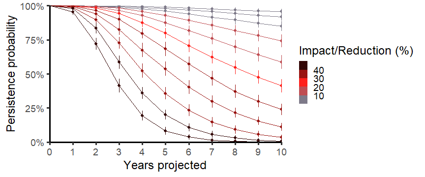

```r
viab_para%>%
  #  mutate(dano=as.factor(dano))%>%
  ggplot(.,aes(x=t-1,y=Persistprop,group=Damage))+
  geom_line(aes(color=Damage*100))+
  geom_pointrange(aes(ymin=ymin, ymax=ymax,color=Damage*100))+
  #  viridis::scale_color_viridis(option="magma")+
  scale_color_stepsn(
    #    colours = c("red", "yellow", "green", "yellow", "red"),
    # colours = viridis::viridis(n = 7, option = "inferno",direction=-1) ,
    colours = Mycolors)+   theme_classic(base_size=24)+
  scale_x_continuous(breaks=seq(0,10,by=1),expand = c(0, 0))+
  scale_y_continuous(labels = scales::percent_format(scale = 1),
                     expand = c(0, 0),
                     breaks=c(seq(0,100,by=25)))+
#  geom_hline(yintercept=10,color="tomato",linetype="dashed")+
  labs(color="Impact/Reduction (%)",
       y="Persistence probability",
       x="Years projected")+
  theme(legend.position="right")
```

```r
viab_para%>%filter(t==10)%>%
  mutate(Extinct.rate=Extinct.rate*100,
         SD=SD*100)
```

| Extinct.rate | SD | Damage | t | Persistprop | ymin | ymax |
| --- | --- | --- | --- | --- | --- | --- |
| 3.68 | 1.7167034 | 0.00 | 10 | 96.32 | 98.0367034 | 94.603297 |
| 7.11 | 2.4366520 | 0.05 | 10 | 92.89 | 95.3266520 | 90.453348 |
| 12.72 | 3.3396304 | 0.10 | 10 | 87.28 | 90.6196304 | 83.940370 |
| 21.88 | 4.1567275 | 0.15 | 10 | 78.12 | 82.2767275 | 73.963272 |
| 35.79 | 5.1390661 | 0.20 | 10 | 64.21 | 69.3490661 | 59.070934 |
| 52.38 | 4.8027349 | 0.25 | 10 | 47.62 | 52.4227349 | 42.817265 |
| 70.00 | 4.6384428 | 0.30 | 10 | 30.00 | 34.6384428 | 25.361557 |
| 84.47 | 3.0065753 | 0.35 | 10 | 15.53 | 18.5365753 | 12.523425 |
| 94.17 | 2.4579494 | 0.40 | 10 | 5.83 | 8.2879494 | 3.372051 |
| 98.52 | 1.2671450 | 0.45 | 10 | 1.48 | 2.7471450 | 0.212855 |

[output cut: 1 more lines]

```r
viab_S11B<-do.call(rbind,outS11B)%>%
  mutate(Persistprop=100-(Extinct.rate*100),
         ymin=100-((Extinct.rate-SD)*100),
         ymax=100-((Extinct.rate+SD)*100))


viab_S11B[viab_S11B>100]<-100
viab_S11B[viab_S11B<0]<-0

viab_S11C<-do.call(rbind,outS11C)%>%
  mutate(Persistprop=100-(Extinct.rate*100),
         ymin=100-((Extinct.rate-SD)*100),
         ymax=100-((Extinct.rate+SD)*100))

viab_S11C[viab_S11C>100]<-100
viab_S11C[viab_S11C<0]<-0



viab_S11B%>%filter(t==10)%>%filter(t==10)%>%
  mutate(Extinct.rate=Extinct.rate*100,
         SD=SD*100)
```

| Extinct.rate | SD | Damage | t | verbose | Persistprop | ymin | ymax |
| --- | --- | --- | --- | --- | --- | --- | --- |
| 16.30 | 3.4038006 | 0.00 | 10 | FALSE | 83.70 | 87.1038006 | 80.29619939 |
| 24.52 | 4.6176648 | 0.05 | 10 | FALSE | 75.48 | 80.0976648 | 70.86233519 |
| 37.37 | 4.6550830 | 0.10 | 10 | FALSE | 62.63 | 67.2850830 | 57.97491697 |
| 51.76 | 5.4774469 | 0.15 | 10 | FALSE | 48.24 | 53.7174469 | 42.76255313 |
| 65.67 | 5.5524223 | 0.20 | 10 | FALSE | 34.33 | 39.8824223 | 28.77757765 |
| 79.70 | 3.9733964 | 0.25 | 10 | FALSE | 20.30 | 24.2733964 | 16.32660362 |
| 89.90 | 2.8972296 | 0.30 | 10 | FALSE | 10.10 | 12.9972296 | 7.20277039 |
| 96.14 | 2.0001010 | 0.35 | 10 | FALSE | 3.86 | 5.8601010 | 1.85989899 |
| 98.77 | 1.2048303 | 0.40 | 10 | FALSE | 1.23 | 2.4348303 | 0.02516965 |
| 99.83 | 0.3775252 | 0.45 | 10 | FALSE | 0.17 | 0.5475252 | 0.00000000 |

[output cut: 1 more lines]

```r
viab_S11C%>%filter(t==10)%>%filter(t==10)%>%
  mutate(Extinct.rate=Extinct.rate*100,
         SD=SD*100)
```

| Extinct.rate | SD | Damage | t | verbose | Persistprop | ymin | ymax |
| --- | --- | --- | --- | --- | --- | --- | --- |
| 0.10 | 0.3015113 | 0.00 | 10 | FALSE | 99.90 | 100.000000 | 99.598489 |
| 0.37 | 0.5623723 | 0.05 | 10 | FALSE | 99.63 | 100.000000 | 99.067628 |
| 1.47 | 1.1845384 | 0.10 | 10 | FALSE | 98.53 | 99.714538 | 97.345462 |
| 4.21 | 1.8978723 | 0.15 | 10 | FALSE | 95.79 | 97.687872 | 93.892128 |
| 10.86 | 3.3303623 | 0.20 | 10 | FALSE | 89.14 | 92.470362 | 85.809638 |
| 23.20 | 4.3344987 | 0.25 | 10 | FALSE | 76.80 | 81.134499 | 72.465501 |
| 42.24 | 4.1708948 | 0.30 | 10 | FALSE | 57.76 | 61.930895 | 53.589105 |
| 65.28 | 4.6841232 | 0.35 | 10 | FALSE | 34.72 | 39.404123 | 30.035877 |
| 84.72 | 3.5535727 | 0.40 | 10 | FALSE | 15.28 | 18.833573 | 11.726427 |
| 95.54 | 2.3286533 | 0.45 | 10 | FALSE | 4.46 | 6.788653 | 2.131347 |

[output cut: 1 more lines]

```r
NA
NA
```

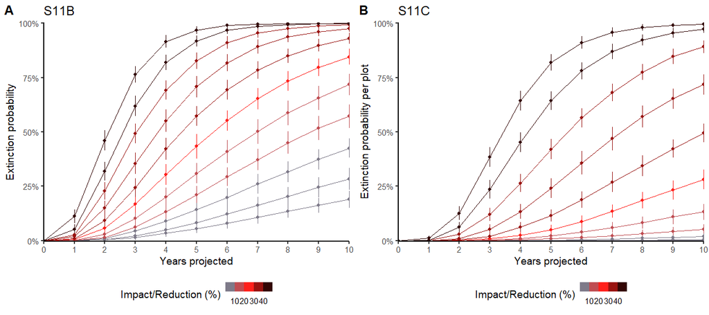

```r
cowplot::plot_grid(labels = "AUTO",label_size=24,
  do.call(rbind,outS11B)%>%
  #  mutate(dano=as.factor(dano))%>%
  ggplot(.,aes(x=t-1,y=Extinct.rate*100,group=Damage))+
  geom_line(aes(color=Damage*100))+
  geom_pointrange(aes(ymin=(Extinct.rate-SD)*100, ymax=(Extinct.rate+SD)*100,color=Damage*100))+
  #  viridis::scale_color_viridis(option="magma")+
  scale_color_stepsn(
    #    colours = c("red", "yellow", "green", "yellow", "red"),
    # colours = viridis::viridis(n = 7, option = "inferno",direction=-1) ,
    colours = Mycolors)+   theme_classic(base_size=19)+
  scale_x_continuous(breaks=seq(0,10,by=1),expand = c(0, 0))+
  scale_y_continuous(labels = scales::percent_format(scale = 1),
                     expand = c(0, 0),
                     breaks=c(seq(0,100,by=25)))+
  labs(color="Impact/Reduction (%)",
       y="Extinction probability",
       x="Years projected",
       title="S11B")+
  theme(legend.position="bottom"),


  do.call(rbind,outS11C)%>%
  #  mutate(dano=as.factor(dano))%>%
  ggplot(.,aes(x=t-1,y=Extinct.rate*100,group=Damage))+
  geom_line(aes(color=Damage*100))+
  geom_pointrange(aes(ymin=(Extinct.rate-SD)*100, ymax=(Extinct.rate+SD)*100,color=Damage*100))+
  #  viridis::scale_color_viridis(option="magma")+
  scale_color_stepsn(
    #    colours = c("red", "yellow", "green", "yellow", "red"),
    # colours = viridis::viridis(n = 7, option = "inferno",direction=-1) ,
    colours = Mycolors)+   theme_classic(base_size=19)+
  scale_x_continuous(breaks=seq(0,10,by=1),expand = c(0, 0))+
  scale_y_continuous(labels = scales::percent_format(scale = 1),
                     expand = c(0, 0),
                     breaks=c(seq(0,100,by=25)))+
  labs(color="Impact/Reduction (%)",
       y="Extinction probability per plot",
       x="Years projected",
       title="S11C")+
  theme(legend.position="bottom")
)
```

```r
NA
NA
```

# Glossary

**C**

C: is a matrix somehow